# From Man vs. Machine to Man + Machine

Bhaswar Chakma

2025-05-02

## A Moment in History: Man vs. Machine

[figure not shown]

- In 1997, world champion Garry Kasparov lost to IBM’s Deep Blue.

## From Adversaries to Allies

- After losing, Kasparov didn’t give up — he adapted.
- He introduced “centaur chess”, pairing human intuition with machine power.

## From Chess to Finance

Kasparov’s idea of man + machine wasn’t just for chess.

This study brings that question into finance:

- Can human analysts and AI models compete — or collaborate — in forecasting the market?
- To explore this, the authors created an AI analyst and compared it to real professionals.

## Meet the Analysts

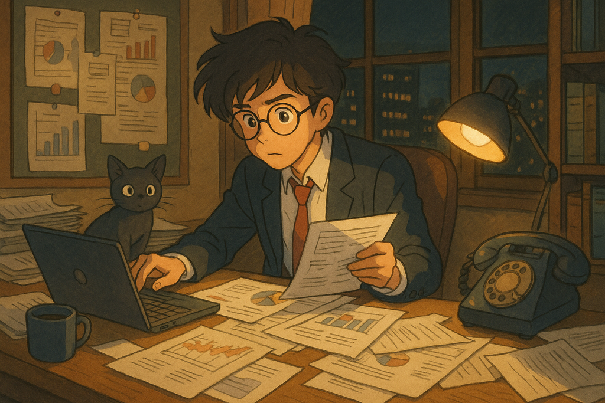

Human Analyst

- Uses intuition and experience
- Reads disclosures, meets firms
- Prone to cognitive or incentive bias

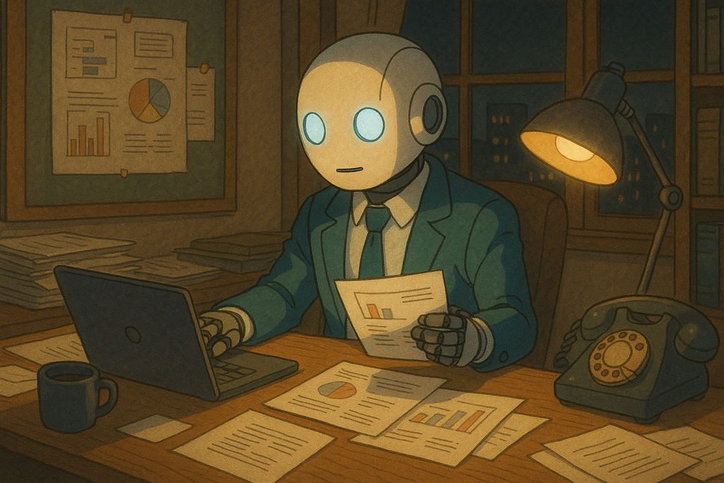

AI Analyst

- Absorbs massive data
- Fast, consistent, unbiased
- But lacks nuance or context

## The Prediction Setup

In this study, both human and AI analysts forecast 12-month-ahead stock returns using target prices.

- Target prices reflect analysts’ valuation beliefs
- Predicted return = (Target – Current Price) / Current Price
- Target prices are preferred over earnings forecasts:
  - Reflect longer-term firm value
  - Less affected by short-term managerial manipulation

## Research Questions

This study addresses three core questions:

1. Can an AI analyst predict 12-month-ahead stock returns more accurately than human analysts?
2. When do human analysts outperform AI — and why?
3. Does combining AI and human forecasts improve accuracy and reduce large errors?

## Methodology: Overview

- The authors construct an AI analyst using machine learning
- The model forecasts 12-month-ahead stock returns derived from target prices
- Each forecast is based on a rolling 3-year window of past data, simulating real-time prediction
- Human forecasts are not used as inputs — predictions are made entirely from public information

## Methodology: Modeling Approach

The AI analyst uses an ensemble of machine learning models:

- Long Short-Term Memory (LSTM) networks — capture sequential patterns in financial time series
- Random forest — robust to noise and effective with many predictors
- Gradient boosting — excels at handling non-linear relationships and variable interactions
- The ensemble integrates strengths of each model to improve predictive accuracy and robustness.

## The Data: Sample Overview

- **Data sources:**
  - I/B/E/S, Compustat, CRSP (structured data)
  - RavenPack (news sentiment), Twitter (social media)
  - SEC EDGAR (filings), Kogan et al. (patents)
- Over 1.15 million target price forecasts, covering thousands of U.S. firms
- Coverage spans all major sectors, firm sizes, and time periods (2001–2018)

## The Data: AI Analyst Input Overview

The AI analyst is trained on a wide variety of publicly available information.

- Human analyst data: I/B/E/S target prices (2001–2018)
- AI model: trained on 3 years of historical data prior to each forecast
- Forecast target: 12-month stock return based on target price

## The Data: Categories of inputs

The model draws from six key categories of inputs:

[output not shown]

## The Data: Structured Inputs

**Firm Data:** - Size, book-to-market, ROA - Leverage, accruals - Past returns (1–36 months), volatility - Amihud illiquidity

**Industry Data:** - Fama-French industry groupings - Industry competition (text-based) - Product market fluidity

**Macro Data:** - GDP growth, CPI, oil prices - Treasury yields, credit spreads - Market-level illiquidity

## The Data: Textual and Alternative Inputs

**Filings (10-K, 10-Q, 8-K):** - Sentiment and tone (Loughran–McDonald) - Readability and complexity - Text similarity and novelty

**Sentiment:** - RavenPack news sentiment - Twitter-based firm sentiment (Cao et al. 2021a)

**Innovation:** - Patent value estimates (Kogan et al. 2017)

## Results: Performance – AI vs. Human

AI uses only public data, with no access to analyst forecasts or private information.

- The AI analyst outperforms human analysts in approximately 54.5% of stock forecasts.
  - This outperformance is consistent across time, sectors, and market conditions.

## Results: What Drives the AI Analyst?

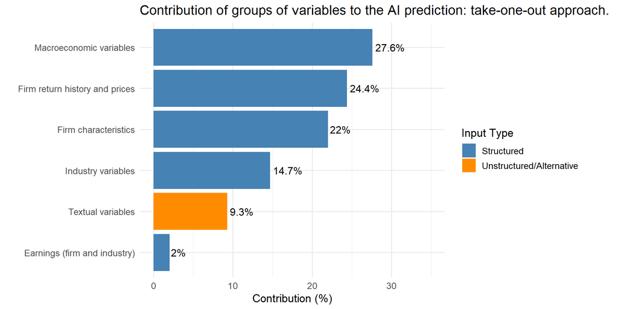

## Results: When Humans Outperform AI

While the AI model performs better overall, human analysts outperform in specific contexts:

- Firms with high intangible assets (e.g. R&D, brand value)
- Firms facing financial distress or complex restructuring
- Stocks with low liquidity or limited trading activity
- Situations requiring qualitative judgment or soft information

## Results: Man + Machine – The Hybrid Model

Combining AI forecasts with analyst predictions and profiles creates a hybrid “centaur” analyst.

- The hybrid model slightly outperforms standalone AI in forecast accuracy.
- It improves consistency and reduces large forecast errors.
- Man + Machine captures the strengths of both:
  - AI’s scale and objectivity
  - Human analysts’ intuition and contextual judgment

## The Hybrid Model Avoids Extreme Errors

- Extreme errors = forecasts in the top 10% of squared prediction errors
- Man + Machine avoids:
  - 90.7% of extreme errors made by human analysts
  - 43.6% of extreme errors made by the AI model